# Geomatic database of REDEC project

The case of Somme (80)

Author

Claude Grasland

The aim of this note is to examine the different statistical and cartographical sources of interest for the objectives of the REDEC project.

# VOTING OFFICES

We use the voting offices as basic territorial units for all the analysis of electoral results.

## The map of INSEE

The geometry of voting offices has been made available only very recently by INSEE through an automatic recognition of the location of adresses on listings [(INSEE, 2023, Proposition de contour des bureaux de vote)](https://www.data.gouv.fr/datasets/proposition-de-contours-des-bureaux-de-vote). The raw map offers a complete coverage of the territory of the departement :

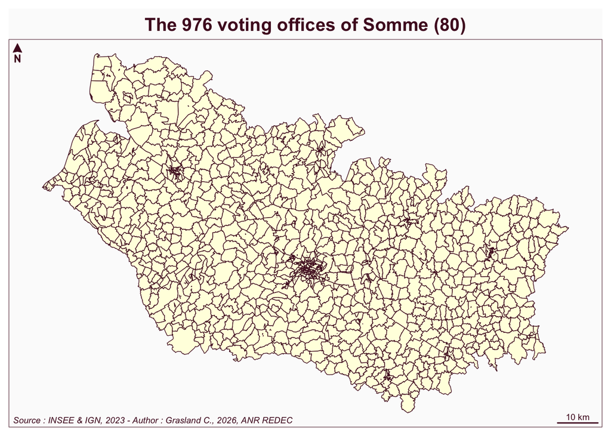

The geometry of map is relatively simple in rural areas where voting offices correspond to the geometry of a commune or an aggregate of communes. But situation is more complex in urban areas.

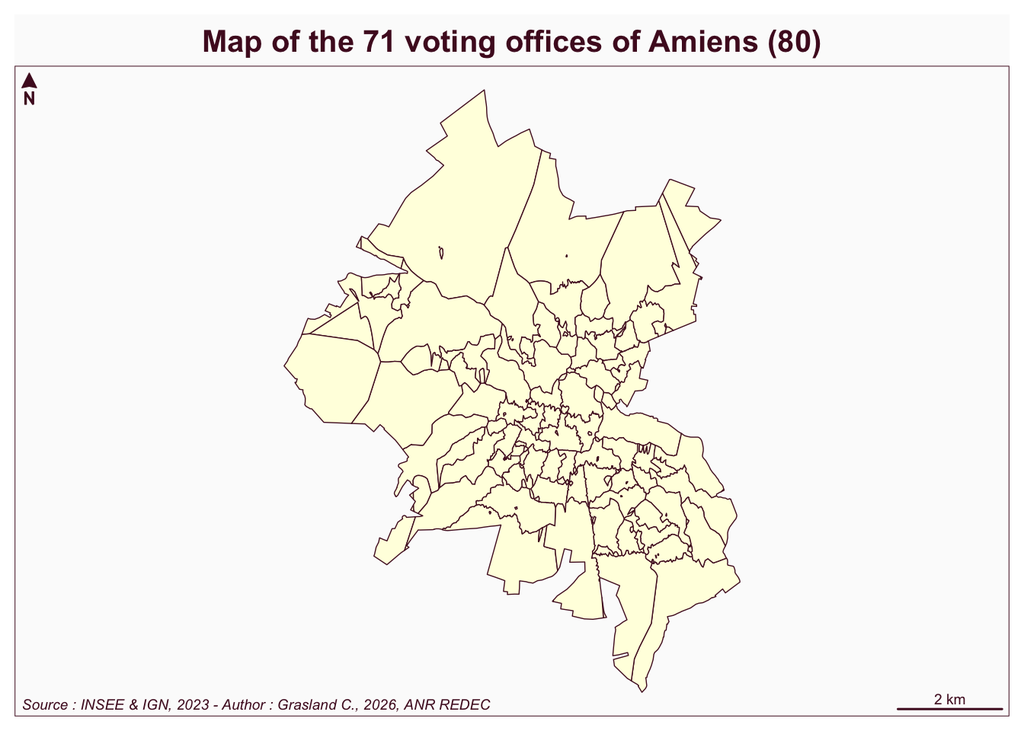

## Generalisation of the map

We have created a simplified map using Voronoï triangulation applied to the geometric center of the area covered by voting offices. As a consequence, some details are lost but the map become more easy to use for topological and spatial analysis.

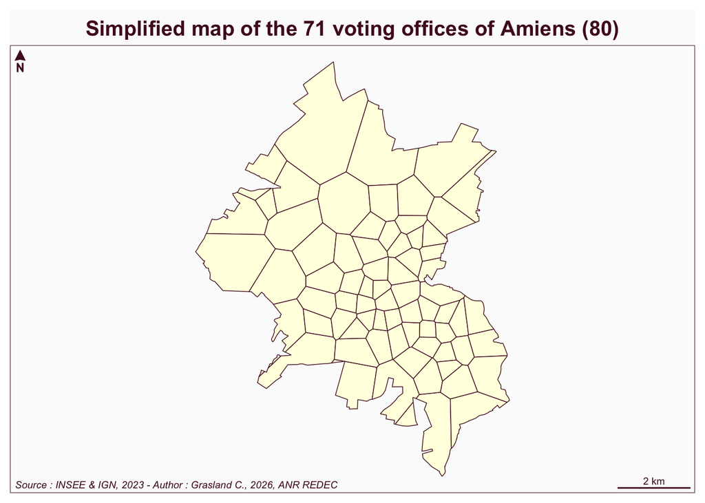

## Cartogram transformation

As we are interested in election, we realize a third version of the map of voting officies where the area is made proportional to the number of registred people (*inscrits*). We use the presidential election of 2022 as reference.

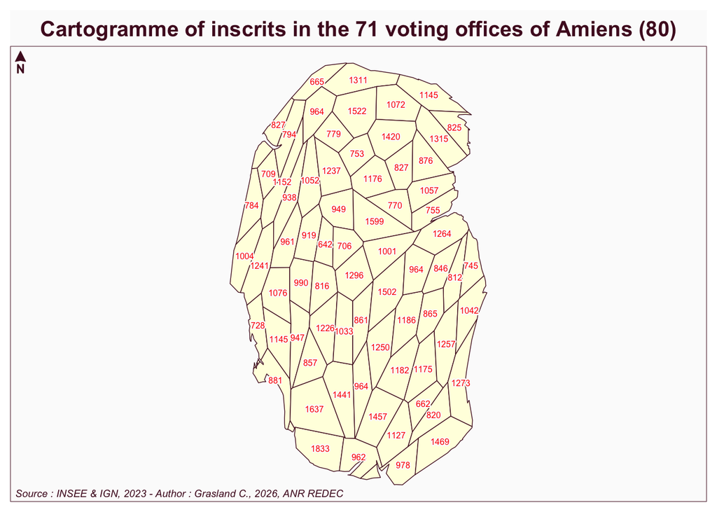

# Cartogram vizualisation

We propose to visualize the number of registered people (*inscrits*) at different levels through cartogrammes.

## 1. Voting offices

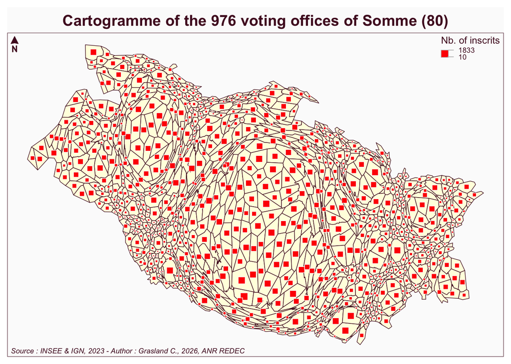

## 2. Communes

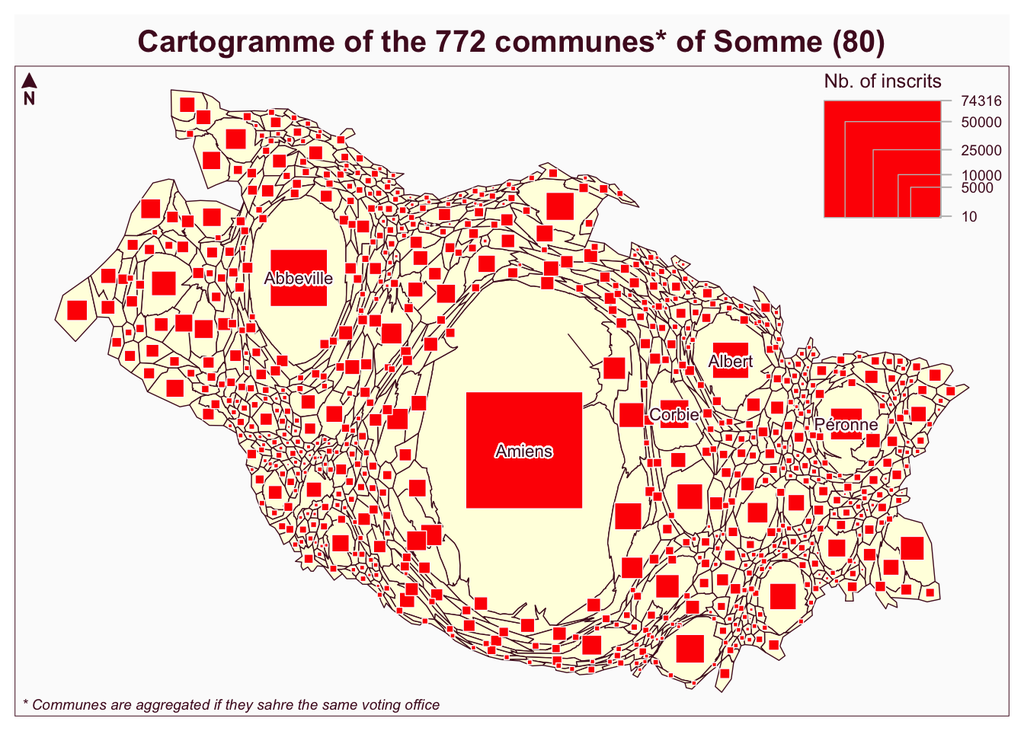

## 3. Cantons

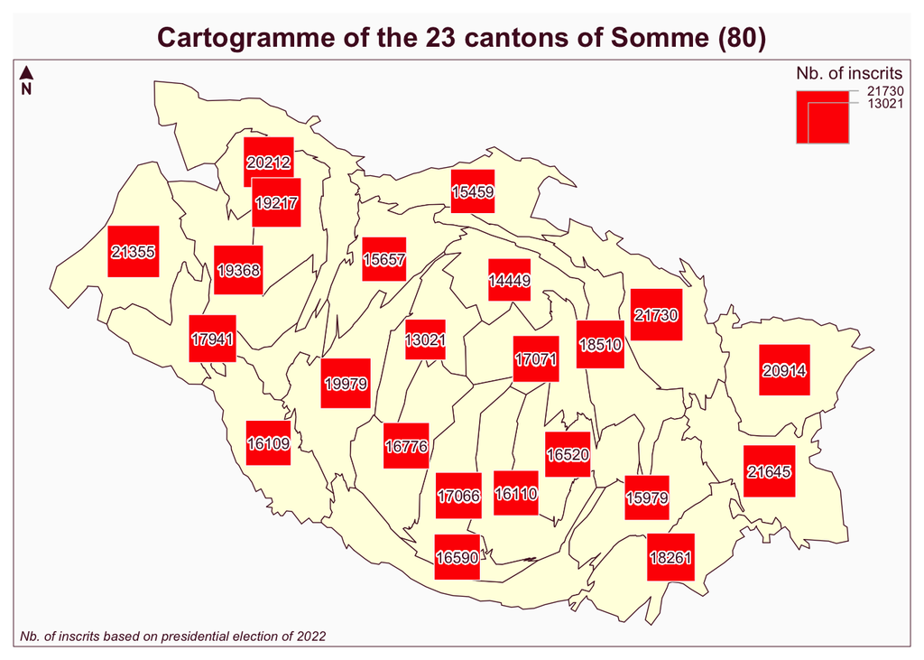

## 4. Circonscriptions

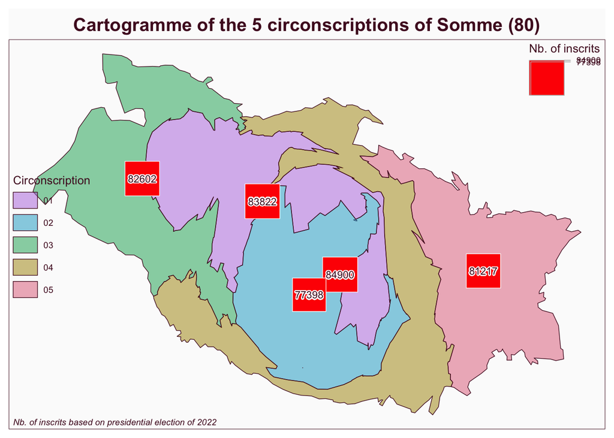

# GRID DATA

## Filosofi 2021

The INSEE grid of population Filosofi at the resolution of 200m x 200m has been published in 2021 with a set of 30 indicators describing the population by age and sex and some economic and social indicator derived from census like the median income of the houshold, the share of social housing, etc. This resolution of 200m is generally sufficient to charactrize the situation of voting office, even if some approximation is requested in central urban area. As an example, here is the distribution of voting office and grid data inthe capital city of the département.

[interactive chart not shown]